# Assignment3

## Importing libraries

Importing necessary libraries for the code below.

```r
# Importing necessary libraries
library(sf)
library(PROJ)
library(tidyverse)
library(ggplot2)
```

## Boston Police District

This is the map data of the Police Districts in Boston (Source: https://data.boston.gov/dataset/police-districts1). I downloaded the Shapefile from the site and imported into RStudio using the library sf. To visualize it, let’s make a simple plot of the map data.

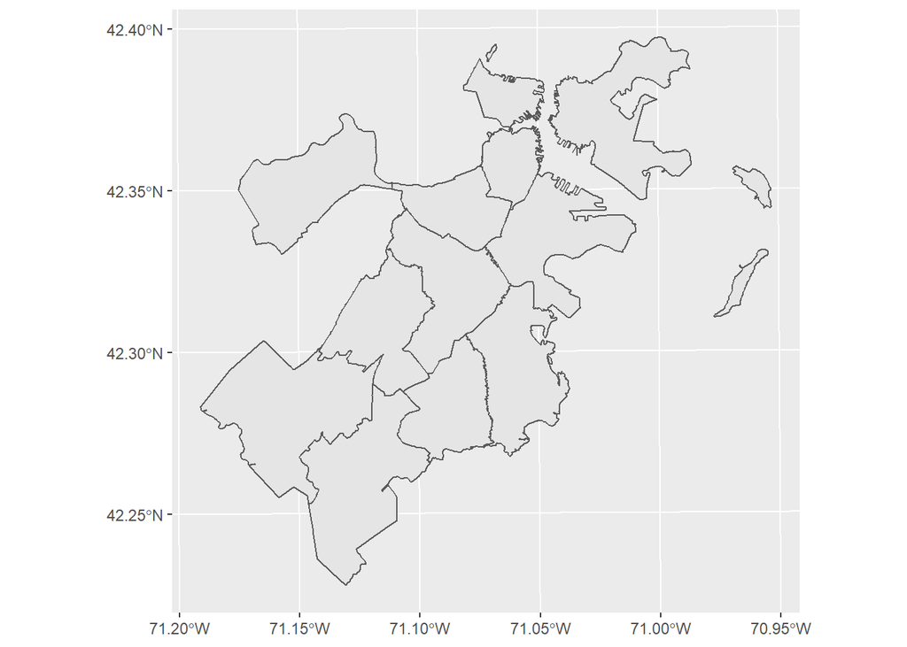

```r
mapData <- st_read("Police_Districts.shp")
map <- ggplot() + geom_sf(data = mapData)
map
```

## Shooting incidents in Boston

**Source: https://data.boston.gov/dataset/shootings**

The data shows the shooting incidents happened in Boston from January 1, 2015 to January 24, 2022. The shootings are divided into where in each police districts it took place. I joined the map data and shooting data by district and then I grouped by district to return a data set with how many shooting incidents happened each police district.

```r
# Importing the data
data <- read.csv("bostonShooting.csv", stringsAsFactors = FALSE)

shootingData <- inner_join(mapData, data, by="DISTRICT")
shootingData
```

```
## Simple feature collection with 1607 features and 15 fields
## Geometry type: MULTIPOLYGON
## Dimension:     XY
## Bounding box:  xmin: 739826.9 ymin: 2908285 xmax: 804052.5 ymax: 2970073
## Projected CRS: NAD83 / Massachusetts Mainland (ftUS)
## First 10 features:
##    OBJECTID DISTRICT  ID BPDGIS_GIS DISTRICT_ DISTRICT__ ShapeSTAre ShapeSTLen
## 1         1      A15 A15          A        15         15   37983921   57616.01
## 2         1      A15 A15          A        15         15   37983921   57616.01
## 3         1      A15 A15          A        15         15   37983921   57616.01
## 4         1      A15 A15          A        15         15   37983921   57616.01
## 5         1      A15 A15          A        15         15   37983921   57616.01
## 6         1      A15 A15          A        15         15   37983921   57616.01
## 7         1      A15 A15          A        15         15   37983921   57616.01
## 8         1      A15 A15          A        15         15   37983921   57616.01
```

[output cut: 35 more lines]

```r
shootingData1 <- shootingData %>% group_by(DISTRICT) %>% summarise(ShootingCount = n())
shootingData1
```

```
## Simple feature collection with 12 features and 2 fields
## Geometry type: MULTIPOLYGON
## Dimension:     XY
## Bounding box:  xmin: 739826.9 ymin: 2908285 xmax: 804052.5 ymax: 2970073
## Projected CRS: NAD83 / Massachusetts Mainland (ftUS)
## # A tibble: 12 x 3
##    DISTRICT ShootingCount                                               geometry
##    <chr>            <int>                        <MULTIPOLYGON [US_survey_foot]>
##  1 A1                  17 (((777233.2 2959748, 777315.3 2959699, 777356.2 29597~
##  2 A15                  9 (((771204.9 2967615, 771205.7 2967613, 771236.6 29676~
##  3 A7                  27 (((792187.3 2969573, 792187.6 2969573, 792188.3 29695~
##  4 B2                 510 (((761060.7 2946239, 761053.8 2946123, 760994.8 29460~
##  5 B3                 397 (((769721.3 2936323, 769742.1 2936300, 769749.8 29363~
##  6 C11                274 (((773840.6 2940789, 773836.1 2940790, 773831.7 29407~
##  7 C6                  48 (((779407 2954364, 779390.5 2954328, 779372 2954290, ~
##  8 D14                 19 (((757306.2 2960067, 757313.1 2960055, 757352 2960076~
##  9 D4                  69 (((771263.4 2955491, 771418.5 2955444, 771590.5 29553~
## 10 E13                130 (((760876.4 2946176, 760884 2946152, 760902.8 2946156~
## 11 E18                 82 (((753345.2 2925395, 753354.5 2925405, 753365.4 29254~
## 12 E5                  25 (((753345.2 2925395, 753346.9 2925396, 753347.5 29253~
```

## Plotting the data onto the map

To understand the data more visually, we can plot the data into our Boston Police District maps to show how many shootings have happened in different areas of the city.

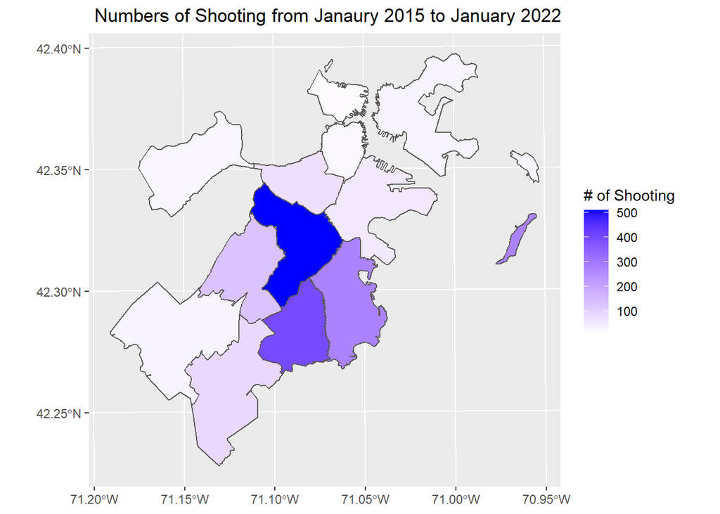

```r
shootingMap <- ggplot() + geom_sf(data=shootingData1) + aes(fill=ShootingCount)

# We can improve the gradient color scale as well as add a better name to the scale
shootingMap1 <- shootingMap + scale_fill_gradient2(midpoint=.1,low = "red",high="blue",mid="white") +
  labs(title = " Numbers of Shooting from Janaury 2015 to January 2022",
       fill = "# of Shooting")
shootingMap1
```

## Conclusion

From the map above, we can see that there is a high number of shooting around the center district hence the darker color, which is district B2. We could make a conclusion that area is not safe because there is a high number of shooting, however we have to keep in mind that the data is the total amount of shooting incidents that happened from January 2015 to January 2022. That area might have a higher population than other districts which may contributes to a higher shooting incidents. We can look closely if we take the the total shootings and divided by the population in that district to get a percentage. In addition, we can also compare this to other cities in Massachusetts, America, and/or other countries.